# VARIABLES DE SALUD

```r
Datacovidof$dim1 <- proyeccionAS$points[,1]
Datacovidof$dim2 <- proyeccionAS$points[,2]

#limites
min(Datacovidof[,c('dim1','dim2')]); max(Datacovidof[,c('dim1','dim2')])
```

```
## [1] -0.3484398
```

```
## [1] 0.9852876
```

```r
limites=c(-0.4,1)
g.dist.cmd_AS = daisy(Datacovidof[,c('dim1','dim2')], metric = 'euclidean')
```

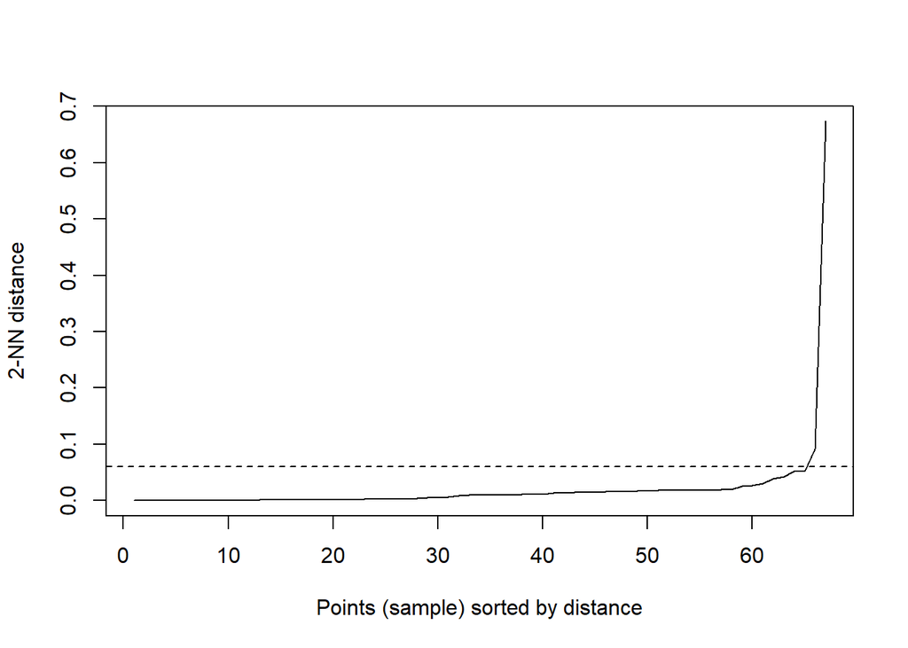

```r
library(dbscan)
kNNdistplot(g.dist.cmd_AS, k=2)
abline(h=0.06,lty=2)
```

```r
library(fpc)
db.cmd_AS= dbscan(g.dist.cmd_AS, eps=0.06, MinPts=2,method = 'dist')
db.cmd_AS
```

```
## dbscan Pts=67 MinPts=2 eps=0.06
##        0  1 2
## border 2  0 0
## seed   0 62 3
## total  2 62 3
```

```r
Datacovidof$dbCMD_AS=as.factor(db.cmd_AS$cluster)
```

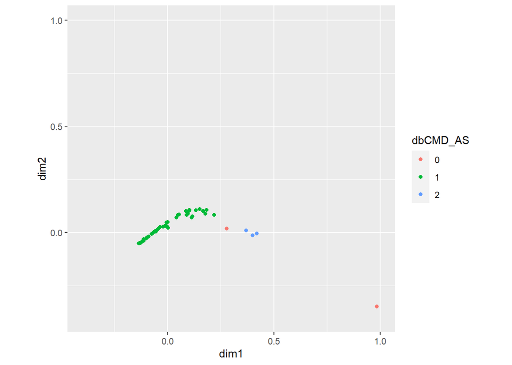

```r
library(ggrepel)
base_AS= ggplot(Datacovidof,aes(x=dim1, y=dim2)) + ylim(limites) + xlim(limites) + coord_fixed()
dbplot_AS= base_AS + geom_point(aes(color=dbCMD_AS))

dbplot_AS
```

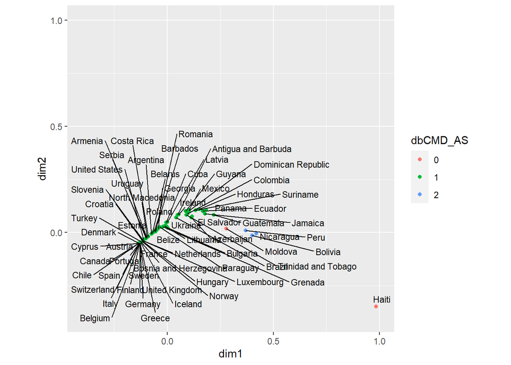

```r
dbplot_AS + geom_text_repel(size=3,aes(label=row.names(Datacovidof[,c(5,6)])))
```

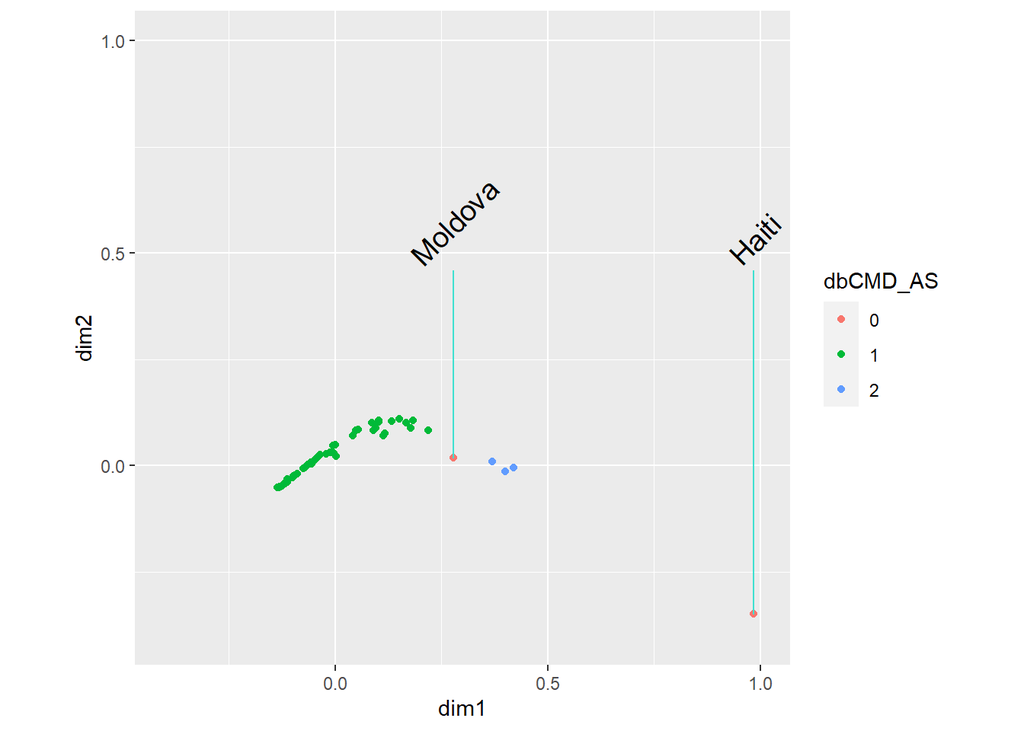

```r
LABEL=ifelse(Datacovidof$dbCMD_AS==0,row.names(Datacovidof[,c(5,6)]),"")
dbplot_AS + geom_text_repel(aes(label=LABEL),
                         size=5,
                         direction = "y", ylim = 0.45,
                         angle=45,
                         segment.colour = "turquoise")
```

```r
Dataclusters=Datacovidof[,c(1,4,18:20,23)]
names(Dataclusters)=c('Pais','Decesos','Salud_PAM','Salud_AG','Salud_DI','Gobernanza_PAM')
```

# Analisis Factorial Exploratorio (EFA) - Mayra Vargas

```r
Datacovidof=na.omit(Datacovidof)
```

```r
COVIDEFA=Datacovidof[,c(5:17)]
```

```r
library(polycor)
MatrixCovid=polycor::hetcor(COVIDEFA)$correlations
```

#Explorar Correlaciones #Sin evaluar significancia

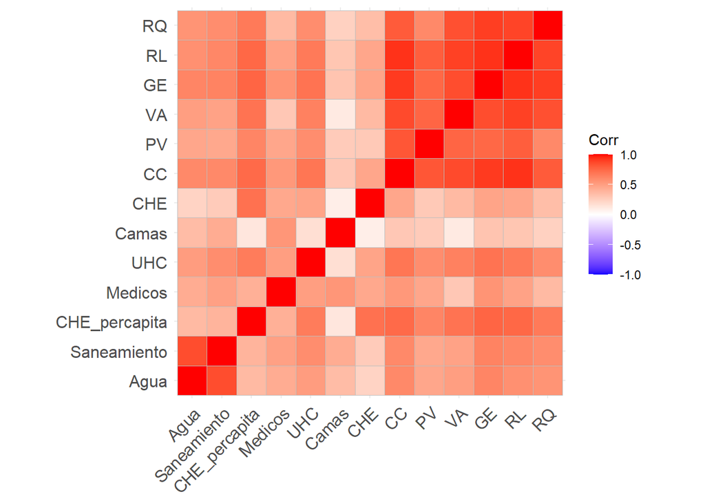

```r
library(ggcorrplot)
ggcorrplot(MatrixCovid)
```

#Evaluando significancia

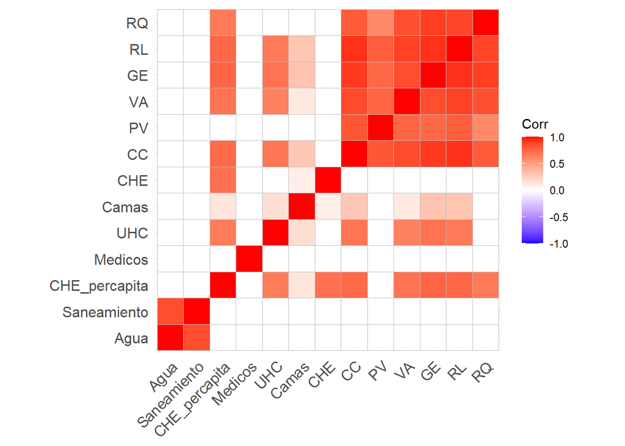

```r
ggcorrplot(MatrixCovid,
          p.mat = cor_pmat(MatrixCovid),
          insig = "blank")
```

#KMO

```r
library(psych)
psych::KMO(MatrixCovid)
```

```
## Kaiser-Meyer-Olkin factor adequacy
## Call: psych::KMO(r = MatrixCovid)
## Overall MSA =  0.88
## MSA for each item =
##          Agua   Saneamiento CHE_percapita       Medicos           UHC
##          0.82          0.81          0.89          0.84          0.92
##         Camas           CHE            CC            PV            VA
##          0.80          0.74          0.93          0.90          0.92
##            GE            RL            RQ
##          0.92          0.90          0.85
```

#Pruebas #HNula: para matriz identidad

```r
cortest.bartlett(MatrixCovid,n=nrow(COVIDEFA))$p.value>0.05
```

```
## [1] FALSE
```

#Hnula: para matriz singular

```r
library(matrixcalc)
is.singular.matrix(MatrixCovid)
```

```
## [1] FALSE
```

#Redimensionar

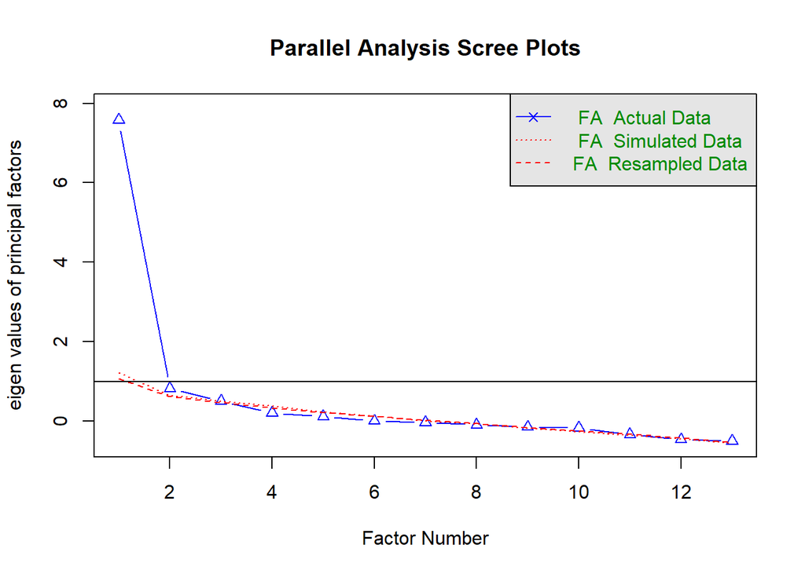

```
## Parallel analysis suggests that the number of factors =  2  and the number of components =  NA
```

```r
fa.parallel(COVIDEFA,fm = 'ML', fa = 'fa')
```

#Primer resultado

```r
library(GPArotation)
resulefa=fa(COVIDEFA,nfactors = 2,cor = 'mixed',rotate = "varimax",fm="minres")
```

```r
print(resulefa$loadings)
```

```
##
## Loadings:
##               MR1   MR2
## Agua          0.350 0.732
## Saneamiento   0.333 0.845
## CHE_percapita 0.831 0.141
## Medicos       0.339 0.554
## UHC           0.649 0.374
## Camas               0.556
## CHE           0.496 0.147
## CC            0.864 0.404
## PV            0.720 0.306
## VA            0.895 0.178
## GE            0.861 0.432
## RL            0.894 0.370
## RQ            0.787 0.334
##
##                  MR1   MR2
## SS loadings    5.936 2.771
## Proportion Var 0.457 0.213
## Cumulative Var 0.457 0.670
```

#Resultado mejorado

```r
print(resulefa$loadings,cutoff = 0.5)
```

```
##
## Loadings:
##               MR1   MR2
## Agua                0.732
## Saneamiento         0.845
## CHE_percapita 0.831
## Medicos             0.554
## UHC           0.649
## Camas               0.556
## CHE
## CC            0.864
## PV            0.720
## VA            0.895
## GE            0.861
## RL            0.894
## RQ            0.787
##
##                  MR1   MR2
## SS loadings    5.936 2.771
## Proportion Var 0.457 0.213
## Cumulative Var 0.457 0.670
```

#Visualizamos

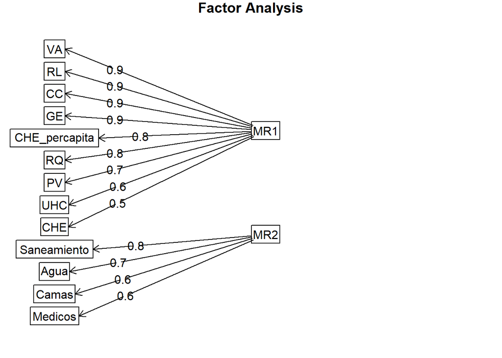

```r
fa.diagram(resulefa)
```

#Evaluación #¿La Raíz del error cuadrático medio corregida está cerca a cero?

```r
resulefa$crms
```

```
## [1] 0.08239574
```

#¿La Raíz del error cuadrático medio de aproximación es menor a 0.05?

```r
resulefa$RMSEA
```

```
##      RMSEA      lower      upper confidence
##  0.1762054  0.1476160  0.2094905  0.9000000
```

#¿El índice de Tucker-Lewis es mayor a 0.9?

```r
resulefa$TLI
```

```
## [1] 0.8023441
```

#¿Qué variables aportaron mas a los factores?

```r
sort(resulefa$communality)
```

```
##           CHE         Camas       Medicos           UHC            PV
##     0.2679057     0.3138029     0.4217295     0.5606282     0.6117942
##          Agua CHE_percapita            RQ   Saneamiento            VA
##     0.6588169     0.7101397     0.7310945     0.8247676     0.8328148
##            CC            GE            RL
##     0.9089611     0.9286548     0.9358971
```

#¿Qué variables contribuyen a mas de un factor?

```r
sort(resulefa$complexity)
```

```
##         Camas CHE_percapita            VA           CHE   Saneamiento
##      1.027863      1.057921      1.078813      1.174052      1.302415
##            RL            RQ            PV            CC          Agua
##      1.332106      1.347796      1.349005      1.416642      1.434539
##            GE           UHC       Medicos
##      1.474242      1.597804      1.656630
```

# Regresión lineal (Gonzalo Berger)

```r
regDatacovid=Datacovidof[,c(4:17)]
```

```r
library(stargazer)
Modelo1=formula(Decesos~CC)
Modelo2=formula(Decesos~CC+PV)
Modelo3=formula(Decesos~CC+PV+VA)
Modelo4=formula(Decesos~CC+PV+VA+GE)
Modelo5=formula(Decesos~CC+PV+VA+GE+RL)
Modelo6=formula(Decesos~CC+PV+VA+GE+RL+RQ)
```

```r
reg1cov=lm(Modelo1,data=regDatacovid)
stargazer(reg1cov,type='text',intercept.bottom = F)
```

```
##
## ===============================================
##                         Dependent variable:
##                     ---------------------------
##                               Decesos
## -----------------------------------------------
## Constant                      80.628
##                              (60.059)
##
## CC                             1.505
##                               (0.910)
##
## -----------------------------------------------
## Observations                    67
## R2                             0.040
## Adjusted R2                    0.026
## Residual Std. Error      198.719 (df = 65)
## F Statistic             2.737 (df = 1; 65)
## ===============================================
## Note:               *p<0.1; **p<0.05; ***p<0.01
```

```r
reg2cov=lm(Modelo2,data=regDatacovid)
stargazer(reg2cov,type='text',intercept.bottom = F)
```

```
##
## ===============================================
##                         Dependent variable:
##                     ---------------------------
##                               Decesos
## -----------------------------------------------
## Constant                     150.228**
##                              (61.856)
##
## CC                           5.050***
##                               (1.502)
##
## PV                           -5.063***
##                               (1.757)
##
## -----------------------------------------------
## Observations                    67
## R2                             0.151
## Adjusted R2                    0.124
## Residual Std. Error      188.416 (df = 64)
## F Statistic            5.674*** (df = 2; 64)
## ===============================================
## Note:               *p<0.1; **p<0.05; ***p<0.01
```

```r
reg3cov=lm(Modelo3,data=regDatacovid)
stargazer(reg3cov,type='text',intercept.bottom = F)
```

```
##
## ===============================================
##                         Dependent variable:
##                     ---------------------------
##                               Decesos
## -----------------------------------------------
## Constant                      77.686
##                              (65.572)
##
## CC                             1.974
##                               (1.867)
##
## PV                           -5.874***
##                               (1.713)
##
## VA                            4.606**
##                               (1.780)
##
## -----------------------------------------------
## Observations                    67
## R2                             0.232
## Adjusted R2                    0.196
## Residual Std. Error      180.555 (df = 63)
## F Statistic            6.350*** (df = 3; 63)
## ===============================================
## Note:               *p<0.1; **p<0.05; ***p<0.01
```

```r
reg4cov=lm(Modelo4,data=regDatacovid)
stargazer(reg4cov,type='text',intercept.bottom = F)
```

```
##
## ===============================================
##                         Dependent variable:
##                     ---------------------------
##                               Decesos
## -----------------------------------------------
## Constant                      60.749
##                              (68.909)
##
## CC                             0.707
##                               (2.427)
##
## PV                           -5.790***
##                               (1.720)
##
## VA                            4.130**
##                               (1.877)
##
## GE                             1.908
##                               (2.327)
##
## -----------------------------------------------
## Observations                    67
## R2                             0.240
## Adjusted R2                    0.191
## Residual Std. Error      181.026 (df = 62)
## F Statistic            4.906*** (df = 4; 62)
## ===============================================
## Note:               *p<0.1; **p<0.05; ***p<0.01
```

```r
reg5cov=lm(Modelo5,data=regDatacovid)
stargazer(reg5cov,type='text',intercept.bottom = F)
```

```
##
## ===============================================
##                         Dependent variable:
##                     ---------------------------
##                               Decesos
## -----------------------------------------------
## Constant                      65.446
##                              (73.221)
##
## CC                             0.500
##                               (2.650)
##
## PV                           -5.816***
##                               (1.738)
##
## VA                            3.969*
##                               (2.052)
##
## GE                             1.662
##                               (2.641)
##
## RL                             0.589
##                               (2.908)
##
## -----------------------------------------------
## Observations                    67
## R2                             0.241
## Adjusted R2                    0.179
## Residual Std. Error      182.442 (df = 61)
## F Statistic            3.872*** (df = 5; 61)
## ===============================================
## Note:               *p<0.1; **p<0.05; ***p<0.01
```

```r
reg6cov=lm(Modelo6,data=regDatacovid)
stargazer(reg6cov,type='text',intercept.bottom = F)
```

```
##
## ===============================================
##                         Dependent variable:
##                     ---------------------------
##                               Decesos
## -----------------------------------------------
## Constant                      64.915
##                              (77.159)
##
## CC                             0.521
##                               (2.811)
##
## PV                           -5.800***
##                               (1.869)
##
## VA                            3.952*
##                               (2.196)
##
## GE                             1.620
##                               (3.200)
##
## RL                             0.559
##                               (3.193)
##
## RQ                             0.062
##                               (2.603)
##
## -----------------------------------------------
## Observations                    67
## R2                             0.241
## Adjusted R2                    0.165
## Residual Std. Error      183.956 (df = 60)
## F Statistic            3.174*** (df = 6; 60)
## ===============================================
## Note:               *p<0.1; **p<0.05; ***p<0.01
```

#Análisis de varianza

```r
tanova=anova(reg1cov,reg2cov,reg3cov,reg4cov,reg5cov,reg6cov)
stargazer(tanova,type = 'text',summary = F,title = 'Tabla ANOVA')
```

```
##
## Tabla ANOVA
## ===================================================
##   Res.Df      RSS      Df  Sum of Sq    F   Pr(> F)
## ---------------------------------------------------
## 1   65   2,566,797.000
## 2   64   2,272,035.000 1  294,762.100 8.711  0.005
## 3   63   2,053,811.000 1  218,224.500 6.449  0.014
## 4   62   2,031,761.000 1  22,049.320  0.652  0.423
## 5   61   2,030,397.000 1   1,364.005  0.040  0.842
## 6   60   2,030,378.000 1    18.923    0.001  0.981
## ---------------------------------------------------
```

# Regresion lineal parte 2 - Ivonne Mondoñedo Mora

```r
Modelo7=formula(Decesos~CC+PV+VA+GE+RL+RQ+Agua)
Modelo8=formula(Decesos~CC+PV+VA+GE+RL+RQ+Agua+Saneamiento)
Modelo9=formula(Decesos~CC+PV+VA+GE+RL+RQ+Agua+Saneamiento+CHE_percapita)
Modelo10=formula(Decesos~CC+PV+VA+GE+RL+RQ+Agua+Saneamiento+CHE_percapita+Medicos)
Modelo11=formula(Decesos~CC+PV+VA+GE+RL+RQ+Agua+Saneamiento+CHE_percapita+Medicos+UHC)
Modelo12=formula(Decesos~CC+PV+VA+GE+RL+RQ+Agua+Saneamiento+CHE_percapita+Medicos+UHC+Camas)
Modelo13=formula(Decesos~CC+PV+VA+GE+RL+RQ+Agua+Saneamiento+CHE_percapita+Medicos+UHC+Camas+CHE)
```

```r
reg7cov=lm(Modelo7,data=regDatacovid)
stargazer(reg7cov,type='text',intercept.bottom = F)
```

```
##
## ===============================================
##                         Dependent variable:
##                     ---------------------------
##                               Decesos
## -----------------------------------------------
## Constant                      647.491
##                              (659.533)
##
## CC                             1.029
##                               (2.873)
##
## PV                           -5.860***
##                               (1.874)
##
## VA                            3.772*
##                               (2.210)
##
## GE                             2.095
##                               (3.250)
##
## RL                             0.312
##                               (3.211)
##
## RQ                             0.204
##                               (2.612)
##
## Agua                          -6.377
##                               (7.170)
##
## -----------------------------------------------
## Observations                    67
## R2                             0.251
## Adjusted R2                    0.162
## Residual Std. Error      184.277 (df = 59)
## F Statistic            2.824** (df = 7; 59)
## ===============================================
## Note:               *p<0.1; **p<0.05; ***p<0.01
```

```r
reg8cov=lm(Modelo8,data=regDatacovid)
stargazer(reg8cov,type='text',intercept.bottom = F)
```

```
##
## ===============================================
##                         Dependent variable:
##                     ---------------------------
##                               Decesos
## -----------------------------------------------
## Constant                      787.614
##                              (794.763)
##
## CC                             1.067
##                               (2.897)
##
## PV                           -5.827***
##                               (1.891)
##
## VA                            3.950*
##                               (2.294)
##
## GE                             2.120
##                               (3.276)
##
## RL                             0.005
##                               (3.373)
##
## RQ                             0.177
##                               (2.634)
##
## Agua                          -9.199
##                              (11.368)
##
## Saneamiento                    1.488
##                               (4.629)
##
## -----------------------------------------------
## Observations                    67
## R2                             0.252
## Adjusted R2                    0.149
## Residual Std. Error      185.693 (df = 58)
## F Statistic            2.447** (df = 8; 58)
## ===============================================
## Note:               *p<0.1; **p<0.05; ***p<0.01
```

```r
reg9cov=lm(Modelo9,data=regDatacovid)
stargazer(reg9cov,type='text',intercept.bottom = F)
```

```
##
## ===============================================
##                         Dependent variable:
##                     ---------------------------
##                               Decesos
## -----------------------------------------------
## Constant                      603.709
##                              (781.614)
##
## CC                             0.480
##                               (2.845)
##
## PV                           -5.665***
##                               (1.848)
##
## VA                            3.774*
##                               (2.242)
##
## GE                             0.665
##                               (3.284)
##
## RL                            -0.745
##                               (3.316)
##
## RQ                             0.535
##                               (2.578)
##
## Agua                          -6.644
##                              (11.175)
##
## Saneamiento                    1.787
##                               (4.522)
##
## CHE_percapita                 0.029*
##                               (0.015)
##
## -----------------------------------------------
## Observations                    67
## R2                             0.300
## Adjusted R2                    0.189
## Residual Std. Error      181.301 (df = 57)
## F Statistic            2.709** (df = 9; 57)
## ===============================================
## Note:               *p<0.1; **p<0.05; ***p<0.01
```

```r
reg10cov=lm(Modelo10,data=regDatacovid)
stargazer(reg10cov,type='text',intercept.bottom = F)
```

```
##
## ===============================================
##                         Dependent variable:
##                     ---------------------------
##                               Decesos
## -----------------------------------------------
## Constant                      606.155
##                              (789.018)
##
## CC                             0.504
##                               (2.884)
##
## PV                           -5.647***
##                               (1.876)
##
## VA                             3.698
##                               (2.428)
##
## GE                             0.764
##                               (3.507)
##
## RL                            -0.733
##                               (3.348)
##
## RQ                             0.493
##                               (2.645)
##
## Agua                          -6.693
##                              (11.289)
##
## Saneamiento                    1.852
##                               (4.625)
##
## CHE_percapita                 0.029*
##                               (0.015)
##
## Medicos                       -1.930
##                              (22.336)
##
## -----------------------------------------------
## Observations                    67
## R2                             0.300
## Adjusted R2                    0.175
## Residual Std. Error      182.900 (df = 56)
## F Statistic            2.396** (df = 10; 56)
## ===============================================
## Note:               *p<0.1; **p<0.05; ***p<0.01
```

```r
reg11cov=lm(Modelo11,data=regDatacovid)
stargazer(reg11cov,type='text',intercept.bottom = F)
```

```
##
## ===============================================
##                         Dependent variable:
##                     ---------------------------
##                               Decesos
## -----------------------------------------------
## Constant                     -321.385
##                              (773.398)
##
## CC                             0.366
##                               (2.645)
##
## PV                           -5.620***
##                               (1.720)
##
## VA                             1.688
##                               (2.304)
##
## GE                            -0.660
##                               (3.244)
##
## RL                             0.522
##                               (3.093)
##
## RQ                             1.672
##                               (2.451)
##
## Agua                          -3.046
##                              (10.409)
##
## Saneamiento                   -2.576
##                               (4.437)
##
## CHE_percapita                  0.013
##                               (0.015)
##
## Medicos                       -13.501
##                              (20.768)
##
## UHC                          15.001***
##                               (4.411)
##
## -----------------------------------------------
## Observations                    67
## R2                             0.421
## Adjusted R2                    0.306
## Residual Std. Error      167.760 (df = 55)
## F Statistic           3.640*** (df = 11; 55)
## ===============================================
## Note:               *p<0.1; **p<0.05; ***p<0.01
```

```r
reg12cov=lm(Modelo12,data=regDatacovid)
stargazer(reg12cov,type='text',intercept.bottom = F)
```

```
##
## ===============================================
##                         Dependent variable:
##                     ---------------------------
##                               Decesos
## -----------------------------------------------
## Constant                     -310.851
##                              (780.784)
##
## CC                             0.352
##                               (2.668)
##
## PV                           -5.562***
##                               (1.747)
##
## VA                             1.569
##                               (2.360)
##
## GE                            -0.663
##                               (3.271)
##
## RL                             0.612
##                               (3.134)
##
## RQ                             1.709
##                               (2.475)
##
## Agua                          -3.160
##                              (10.505)
##
## Saneamiento                   -2.330
##                               (4.555)
##
## CHE_percapita                  0.013
##                               (0.015)
##
## Medicos                       -11.178
##                              (22.441)
##
## UHC                          14.776***
##                               (4.516)
##
## Camas                         -3.514
##                              (12.198)
##
## -----------------------------------------------
## Observations                    67
## R2                             0.422
## Adjusted R2                    0.294
## Residual Std. Error      169.176 (df = 54)
## F Statistic           3.288*** (df = 12; 54)
## ===============================================
## Note:               *p<0.1; **p<0.05; ***p<0.01
```

```r
reg13cov=lm(Modelo13,data=regDatacovid)
stargazer(reg13cov,type='text',intercept.bottom = F)
```

```
##
## ===============================================
##                         Dependent variable:
##                     ---------------------------
##                               Decesos
## -----------------------------------------------
## Constant                     -492.135
##                              (776.512)
##
## CC                             0.404
##                               (2.627)
##
## PV                           -4.495**
##                               (1.837)
##
## VA                             1.515
##                               (2.323)
##
## GE                            -0.806
##                               (3.221)
##
## RL                            -0.314
##                               (3.137)
##
## RQ                             2.771
##                               (2.520)
##
## Agua                          -3.515
##                              (10.344)
##
## Saneamiento                   -2.309
##                               (4.485)
##
## CHE_percapita                 -0.006
##                               (0.018)
##
## Medicos                       -22.945
##                              (23.219)
##
## UHC                          14.945***
##                               (4.447)
##
## Camas                         -1.080
##                              (12.100)
##
## CHE                           25.117
##                              (15.245)
##
## -----------------------------------------------
## Observations                    67
## R2                             0.450
## Adjusted R2                    0.316
## Residual Std. Error      166.553 (df = 53)
## F Statistic           3.341*** (df = 13; 53)
## ===============================================
## Note:               *p<0.1; **p<0.05; ***p<0.01
```

```r
tanova_covid=anova(reg1cov,reg2cov,reg3cov,reg4cov,reg5cov,reg6cov,reg7cov,reg8cov,reg9cov,reg10cov,reg11cov,reg12cov,reg13cov)
stargazer(tanova_covid,type = 'text',summary = F,title = 'Tabla ANOVA')
```

```
##
## Tabla ANOVA
## =====================================================
##    Res.Df      RSS      Df  Sum of Sq    F    Pr(> F)
## -----------------------------------------------------
## 1    65   2,566,797.000
## 2    64   2,272,035.000 1  294,762.100 10.626  0.002
## 3    63   2,053,811.000 1  218,224.500 7.867   0.007
## 4    62   2,031,761.000 1  22,049.320  0.795   0.377
## 5    61   2,030,397.000 1   1,364.005  0.049   0.825
## 6    60   2,030,378.000 1    18.923    0.001   0.979
## 7    59   2,003,514.000 1  26,864.440  0.968   0.330
## 8    58   1,999,950.000 1   3,564.251  0.128   0.721
## 9    57   1,873,595.000 1  126,355.200 4.555   0.037
## 10   56   1,873,345.000 1    249.653   0.009   0.925
## 11   55   1,547,892.000 1  325,452.600 11.732  0.001
## 12   54   1,545,517.000 1   2,375.769  0.086   0.771
## 13   53   1,470,219.000 1  75,297.650  2.714   0.105
## -----------------------------------------------------
```

#DIAGNOSTICO DE LA REGRESIÓN #linealidad

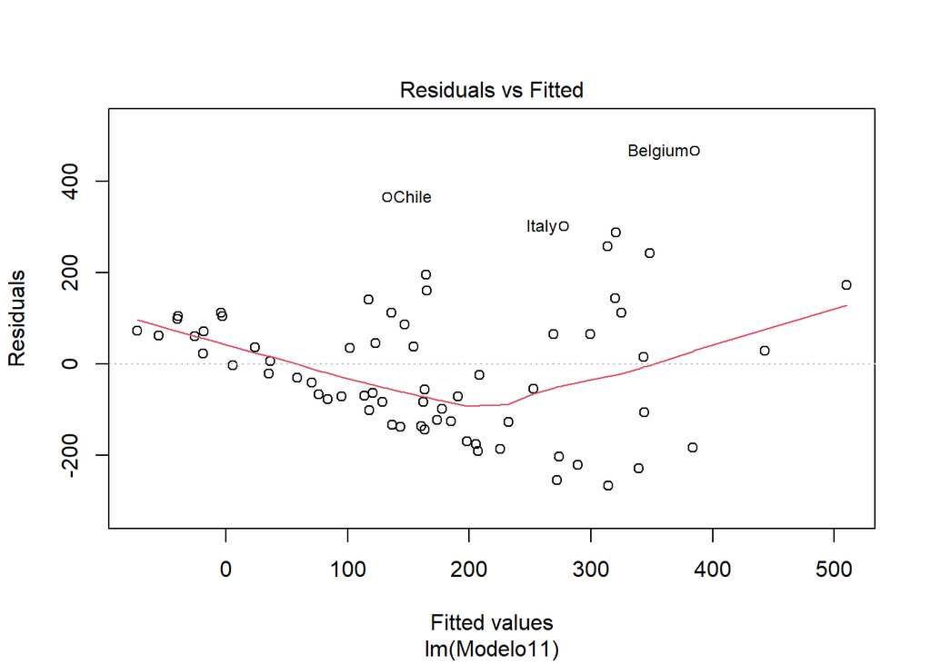

```r
plot(reg11cov,1)
```

#Homocedasticidad

```r
library(lmtest)
```

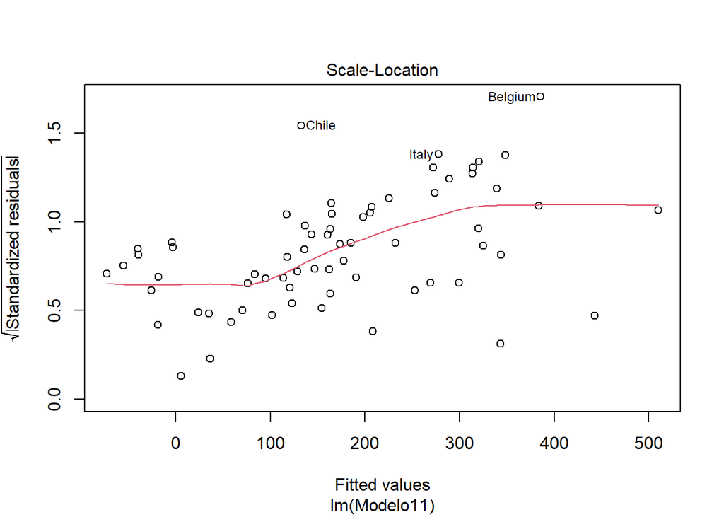

```r
plot(reg11cov,3)
```

```r
bptest(reg11cov)
```

```
##
##  studentized Breusch-Pagan test
##
## data:  reg11cov
## BP = 15.261, df = 11, p-value = 0.1709
```

#Normalidad de residuos

```r
shapiro.test(reg11cov$residuals)
```

```
##
##  Shapiro-Wilk normality test
##
## data:  reg11cov$residuals
## W = 0.96993, p-value = 0.1041
```

#multicolinealidad

```r
library(DescTools)
VIF(reg11cov)
```

```
##            CC            PV            VA            GE            RL
##     11.869124      3.669769      7.641722     14.814031     16.714802
##            RQ          Agua   Saneamiento CHE_percapita       Medicos
##      8.791741      4.304611      4.976820      2.930856      2.094508
##           UHC
##      2.653844
```

#Valores influyentes

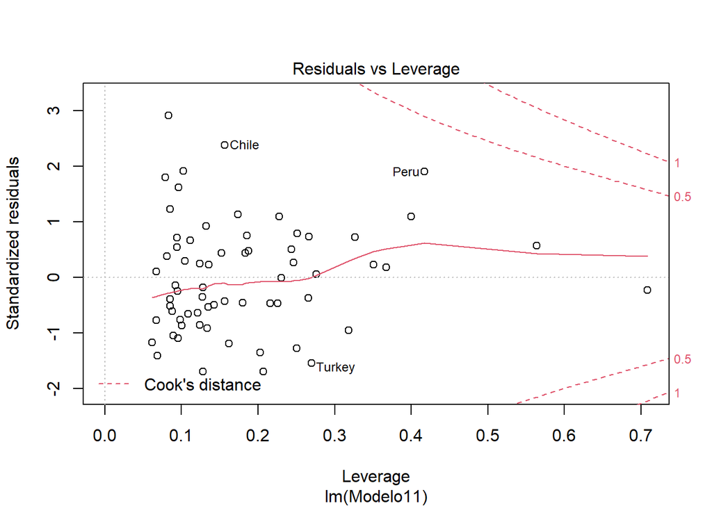

```r
plot(reg11cov, 5)
```

```r
checkReg11=as.data.frame(influence.measures(reg11cov)$is.inf)
head(checkReg11)
```

```
##                     dfb.1_ dfb.CC dfb.PV dfb.VA dfb.GE dfb.RL dfb.RQ dfb.Agua
## Antigua and Barbuda  FALSE  FALSE  FALSE  FALSE  FALSE  FALSE  FALSE    FALSE
## Argentina            FALSE  FALSE  FALSE  FALSE  FALSE  FALSE  FALSE    FALSE
## Armenia              FALSE  FALSE  FALSE  FALSE  FALSE  FALSE  FALSE    FALSE
## Austria              FALSE  FALSE  FALSE  FALSE  FALSE  FALSE  FALSE    FALSE
## Azerbaijan           FALSE  FALSE  FALSE  FALSE  FALSE  FALSE  FALSE    FALSE
## Barbados             FALSE  FALSE  FALSE  FALSE  FALSE  FALSE  FALSE    FALSE
##                     dfb.Snmn dfb.CHE_ dfb.Mdcs dfb.UHC dffit cov.r cook.d   hat
## Antigua and Barbuda    FALSE    FALSE    FALSE   FALSE FALSE FALSE  FALSE FALSE
## Argentina              FALSE    FALSE    FALSE   FALSE FALSE FALSE  FALSE FALSE
## Armenia                FALSE    FALSE    FALSE   FALSE FALSE FALSE  FALSE FALSE
## Austria                FALSE    FALSE    FALSE   FALSE FALSE FALSE  FALSE FALSE
## Azerbaijan             FALSE    FALSE    FALSE   FALSE FALSE  TRUE  FALSE FALSE
## Barbados               FALSE    FALSE    FALSE   FALSE FALSE FALSE  FALSE FALSE
```

```r
checkReg11[checkReg11$cook.d | checkReg11$hat,]
```

```
##       dfb.1_ dfb.CC dfb.PV dfb.VA dfb.GE dfb.RL dfb.RQ dfb.Agua dfb.Snmn
## Cuba   FALSE  FALSE  FALSE  FALSE  FALSE  FALSE  FALSE    FALSE    FALSE
## Haiti  FALSE  FALSE  FALSE  FALSE  FALSE  FALSE  FALSE    FALSE    FALSE
##       dfb.CHE_ dfb.Mdcs dfb.UHC dffit cov.r cook.d  hat
## Cuba     FALSE    FALSE   FALSE FALSE  TRUE  FALSE TRUE
## Haiti    FALSE    FALSE   FALSE FALSE  TRUE  FALSE TRUE
```

```r
Modelo14=formula(Decesos~PV+Agua+Saneamiento+CHE_percapita+Medicos+UHC)
reg14cov=lm(Modelo14,data=regDatacovid)
stargazer(reg14cov,type='text',intercept.bottom = F)
```

```
##
## ===============================================
##                         Dependent variable:
##                     ---------------------------
##                               Decesos
## -----------------------------------------------
## Constant                     -605.307
##                              (712.687)
##
## PV                           -4.103***
##                               (1.243)
##
## Agua                          -0.673
##                               (9.740)
##
## Saneamiento                   -1.169
##                               (4.091)
##
## CHE_percapita                 0.027**
##                               (0.012)
##
## Medicos                       -23.516
##                              (17.674)
##
## UHC                          15.935***
##                               (4.202)
##
## -----------------------------------------------
## Observations                    67
## R2                             0.368
## Adjusted R2                    0.305
## Residual Std. Error      167.792 (df = 60)
## F Statistic            5.835*** (df = 6; 60)
## ===============================================
## Note:               *p<0.1; **p<0.05; ***p<0.01
```

```r
tanova_covid=anova(reg11cov,reg14cov)
stargazer(tanova_covid,type = 'text',summary = F,title = 'Tabla ANOVA')
```

```
##
## Tabla ANOVA
## ====================================================
##   Res.Df      RSS      Df  Sum of Sq     F   Pr(> F)
## ----------------------------------------------------
## 1   55   1,547,892.000
## 2   60   1,689,248.000 -5 -141,356.000 1.005  0.424
## ----------------------------------------------------
```

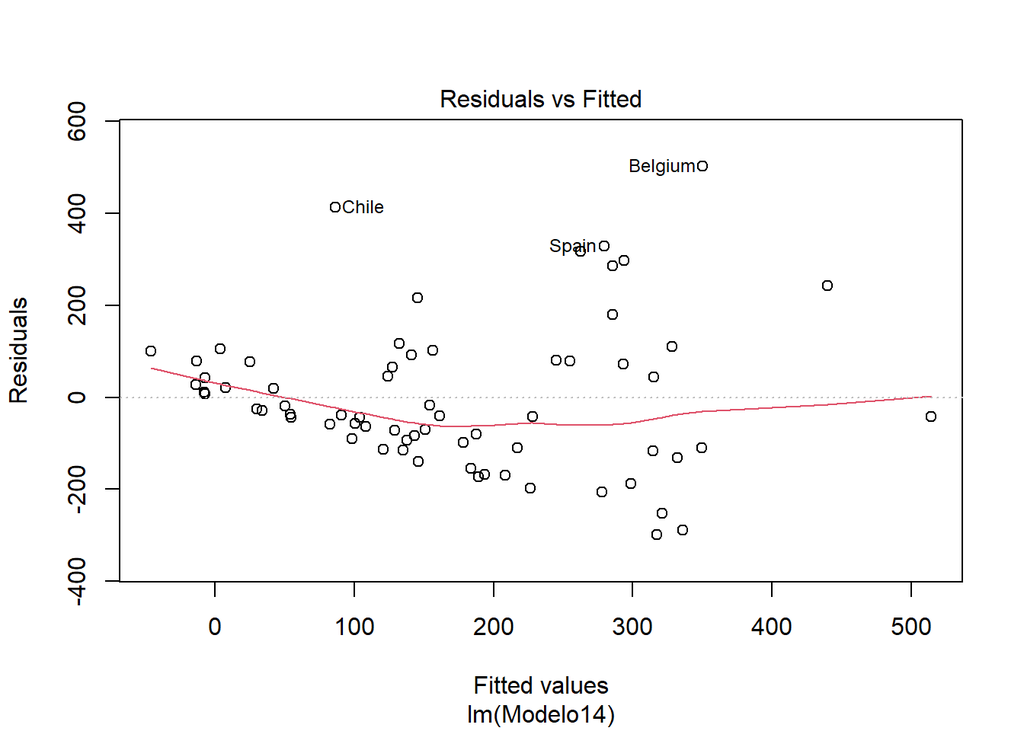

```r
plot(reg14cov,1)
```

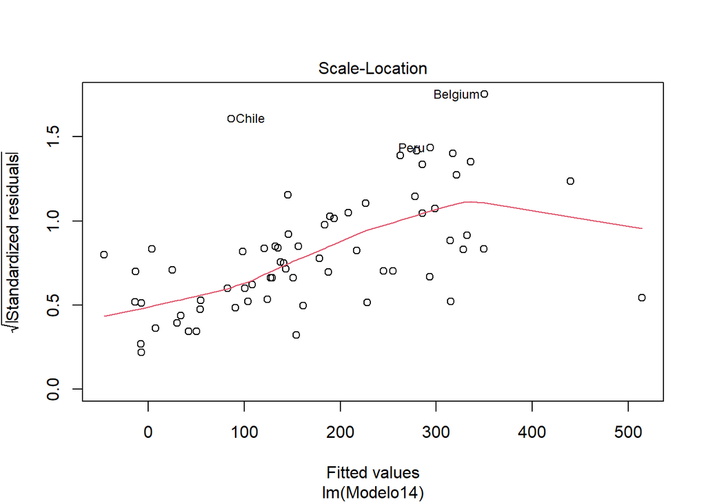

```r
library(lmtest)
plot(reg14cov,3)
```

```r
bptest(reg14cov)
```

```
##
##  studentized Breusch-Pagan test
##
## data:  reg14cov
## BP = 11.646, df = 6, p-value = 0.07036
```

```r
shapiro.test(reg14cov$residuals)
```

```
##
##  Shapiro-Wilk normality test
##
## data:  reg14cov$residuals
## W = 0.94976, p-value = 0.00885
```

```r
library(DescTools)
VIF(reg14cov)
```

```
##            PV          Agua   Saneamiento CHE_percapita       Medicos
##      1.916598      3.767320      4.229073      2.099088      1.516429
##           UHC
##      2.407096
```

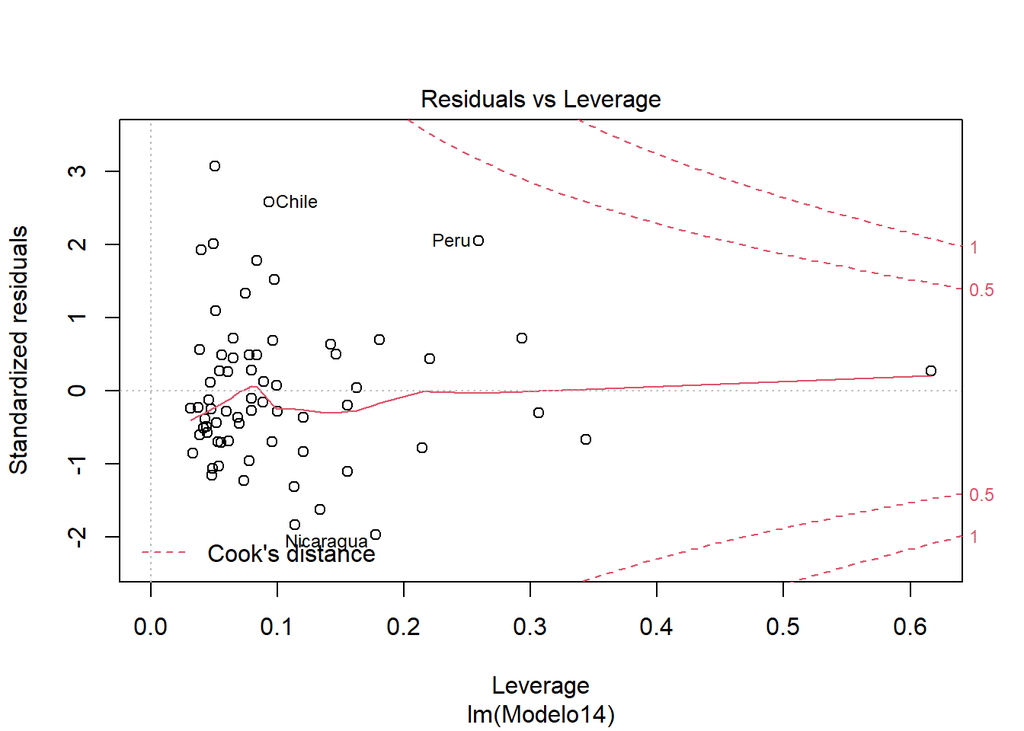

```r
plot(reg14cov, 5)
```

```r
checkReg14=as.data.frame(influence.measures(reg14cov)$is.inf)
head(checkReg14)
```

```
##                     dfb.1_ dfb.PV dfb.Agua dfb.Snmn dfb.CHE_ dfb.Mdcs dfb.UHC
## Antigua and Barbuda  FALSE  FALSE    FALSE    FALSE    FALSE    FALSE   FALSE
## Argentina            FALSE  FALSE    FALSE    FALSE    FALSE    FALSE   FALSE
## Armenia              FALSE  FALSE    FALSE    FALSE    FALSE    FALSE   FALSE
## Austria              FALSE  FALSE    FALSE    FALSE    FALSE    FALSE   FALSE
## Azerbaijan           FALSE  FALSE    FALSE    FALSE    FALSE    FALSE   FALSE
## Barbados             FALSE  FALSE    FALSE    FALSE    FALSE    FALSE   FALSE
##                     dffit cov.r cook.d   hat
## Antigua and Barbuda FALSE FALSE  FALSE FALSE
## Argentina           FALSE FALSE  FALSE FALSE
## Armenia             FALSE FALSE  FALSE FALSE
## Austria             FALSE FALSE  FALSE FALSE
## Azerbaijan          FALSE FALSE  FALSE FALSE
## Barbados            FALSE FALSE  FALSE FALSE
```

```r
checkReg14[checkReg14$cook.d | checkReg14$hat,]
```

```
##       dfb.1_ dfb.PV dfb.Agua dfb.Snmn dfb.CHE_ dfb.Mdcs dfb.UHC dffit cov.r
## Cuba   FALSE  FALSE    FALSE    FALSE    FALSE    FALSE   FALSE FALSE  TRUE
## Haiti  FALSE  FALSE    FALSE    FALSE    FALSE    FALSE   FALSE FALSE  TRUE
##       cook.d  hat
## Cuba   FALSE TRUE
## Haiti  FALSE TRUE
```

```r
regDatacovid=regDatacovid[-c(19,34),]
```

```r
Modelo14=formula(Decesos~PV+Agua+Saneamiento+CHE_percapita+Medicos+UHC)
reg14cov=lm(Modelo14,data=regDatacovid)
stargazer(reg14cov,type='text',intercept.bottom = F)
```

```
##
## ===============================================
##                         Dependent variable:
##                     ---------------------------
##                               Decesos
## -----------------------------------------------
## Constant                     -705.386
##                              (873.462)
##
## PV                           -4.160***
##                               (1.276)
##
## Agua                          -0.341
##                              (10.282)
##
## Saneamiento                   -1.137
##                               (4.447)
##
## CHE_percapita                 0.024*
##                               (0.014)
##
## Medicos                       -16.826
##                              (21.498)
##
## UHC                          16.686***
##                               (4.493)
##
## -----------------------------------------------
## Observations                    65
## R2                             0.361
## Adjusted R2                    0.295
## Residual Std. Error      169.944 (df = 58)
## F Statistic            5.463*** (df = 6; 58)
## ===============================================
## Note:               *p<0.1; **p<0.05; ***p<0.01
```

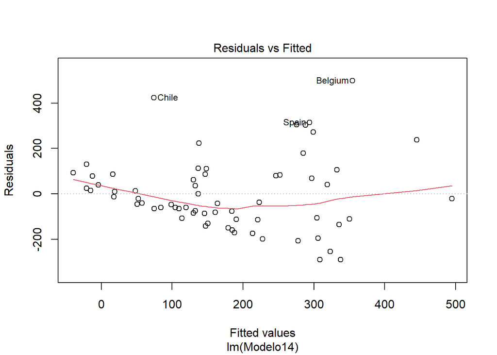

```r
plot(reg14cov,1)
```

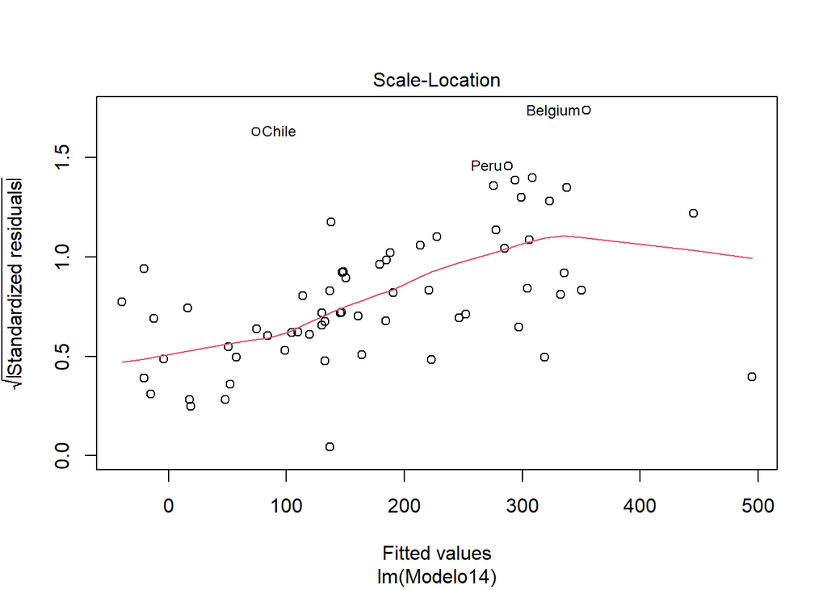

```r
library(lmtest)
plot(reg14cov,3)
```

```r
bptest(reg14cov)
```

```
##
##  studentized Breusch-Pagan test
##
## data:  reg14cov
## BP = 10.352, df = 6, p-value = 0.1106
```

```r
shapiro.test(reg14cov$residuals)
```

```
##
##  Shapiro-Wilk normality test
##
## data:  reg14cov$residuals
## W = 0.95213, p-value = 0.01354
```

```r
library(DescTools)
VIF(reg14cov)
```

```
##            PV          Agua   Saneamiento CHE_percapita       Medicos
##      1.898414      2.194219      2.447167      2.402427      1.619122
##           UHC
##      2.164574
```

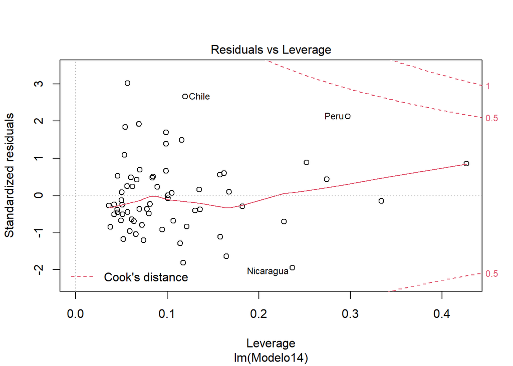

```r
plot(reg14cov, 5)
```

```r
checkReg14=as.data.frame(influence.measures(reg14cov)$is.inf)
head(checkReg14)
```

```
##                     dfb.1_ dfb.PV dfb.Agua dfb.Snmn dfb.CHE_ dfb.Mdcs dfb.UHC
## Antigua and Barbuda  FALSE  FALSE    FALSE    FALSE    FALSE    FALSE   FALSE
## Argentina            FALSE  FALSE    FALSE    FALSE    FALSE    FALSE   FALSE
## Armenia              FALSE  FALSE    FALSE    FALSE    FALSE    FALSE   FALSE
## Austria              FALSE  FALSE    FALSE    FALSE    FALSE    FALSE   FALSE
## Azerbaijan           FALSE  FALSE    FALSE    FALSE    FALSE    FALSE   FALSE
## Barbados             FALSE  FALSE    FALSE    FALSE    FALSE    FALSE   FALSE
##                     dffit cov.r cook.d   hat
## Antigua and Barbuda FALSE FALSE  FALSE FALSE
## Argentina           FALSE FALSE  FALSE FALSE
## Armenia             FALSE FALSE  FALSE FALSE
## Austria             FALSE FALSE  FALSE FALSE
## Azerbaijan          FALSE FALSE  FALSE FALSE
## Barbados            FALSE FALSE  FALSE FALSE
```

```r
checkReg14[checkReg14$cook.d | checkReg14$hat,]
```

```
##               dfb.1_ dfb.PV dfb.Agua dfb.Snmn dfb.CHE_ dfb.Mdcs dfb.UHC dffit
## Bolivia        FALSE  FALSE    FALSE    FALSE    FALSE    FALSE   FALSE FALSE
## United States  FALSE  FALSE    FALSE    FALSE    FALSE    FALSE   FALSE FALSE
##               cov.r cook.d  hat
## Bolivia        TRUE  FALSE TRUE
## United States  TRUE  FALSE TRUE
```